# Lab 9: Team All Stars

Johnny Tamanaha, Emily Archambault, Eugene Miller, Kaiyuan Fan, Jingzhi Zhang

10/25/2019

Domain Expert: Sven Johannson (Economist at Stockholm School of Economics)

## Overall Question:

What factors appear to have the greatest influence on the Happiness Score of a country?

This question is important because understanding the reasons behind what makes the people in some countries happier than others is the key to improving overall happiness for everyone. Finding what the common links are can guide how policies are developed, can shape our understanding of cultures around the world, and can give better insight into the biggest problems facing people today.

## Team Plots:

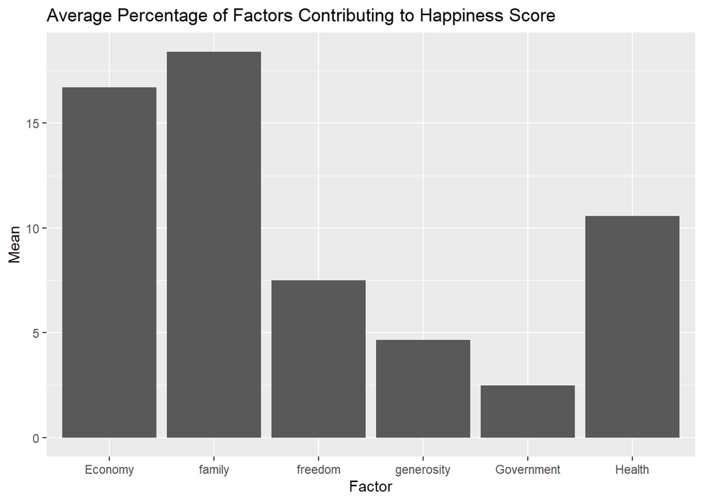

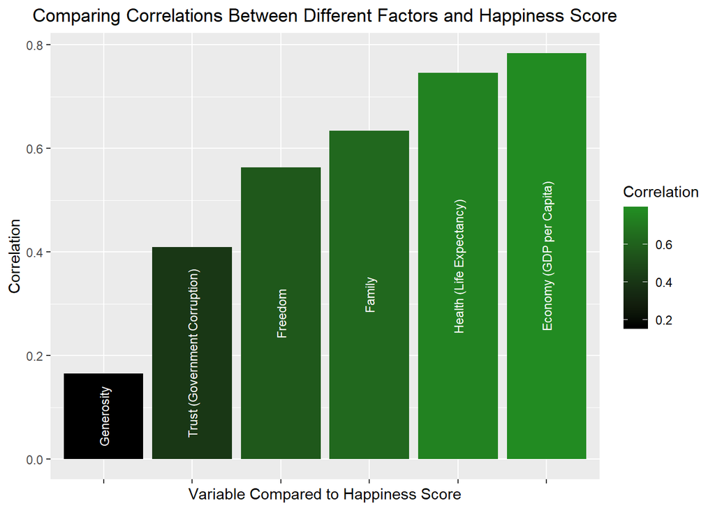

The largest factors affecting happiness score are health and economy, with freedom and family also contributing significantly, wheras generosity and trust seem to be less important in regards to population happiness.

## Recommendation & Why This is Important for Mr. Johannson:

Mr. Johannson wants to know what he should tell world leaders who seek to improve their country’s happiness. We recommend to Mr. Johannson that if a country wishes to improve its overall happiness then the best features to focus on would be economy, health, and family. According to our analysis, these are the largest contributors to overall happiness, and therefore countries that maximize these three factors will also increase their happiness.

## Dataset Description:

The United Nations World Happiness Report is a survey of the state of global happiness. The 2017 report ranks 155 countries by their happiness levels using the happiness scores and rankings use data from the Gallup World Poll. This report estimates the extend to which six variables contribute to happiness score: GDP per Capita, Family, Life Expectancy, Freedom, Generosity, Trust, Government Corruption. Adding these columns up gives happiness score.

## Individual Sections:

### Eugene Miller

How do happiness scores vary by region of the world?

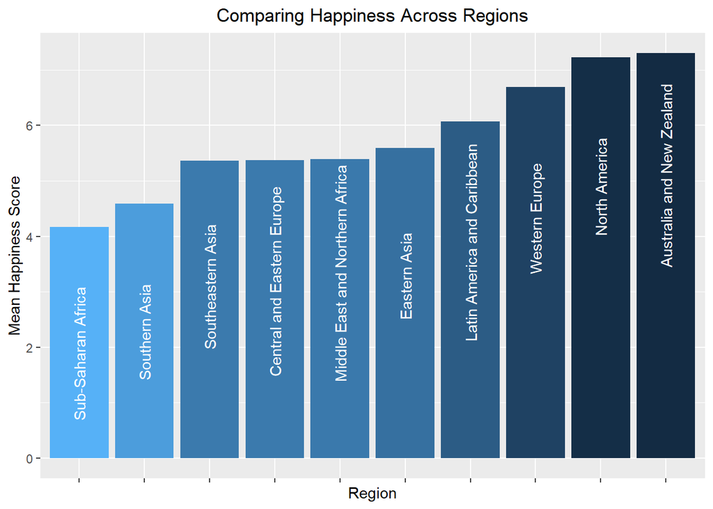

We see that those areas that are happier are generally in the west or setteled by Europeans. This suggest that the greatest factor that influences happiness score is history, and not any individual cultural charecteristic or government policy. This conclusions is also supported by the team plot, where economy and health (which is correlated to economy) are the largest factors that affect happiness and generally western economies are more wealthy than economies who were exploted for their resources.

Another interesting question to ask is; do the happiest countries have a low or high standard deviation across individual scores for family, corruption, gdp per capita etc?

The top 5 happiest countries have standard deviations of: 0.4650902, 0.4963003, 0.5696693, 0.4289243, 0.4269188 between individual scores. Whereas the 5 least happy have standard deviations of: 0.2342836, 0.1378861, 0.0768438, 0.2153145, 0.0966601 between their scores. This suggests that happy countries have a strong score in one area and good scores in all others, while unhappy countries may have one very poor score, but overall their scores are not very high, and are closer to each other than those of happy countries.

### Emily Archambault:

How does the average trust in government percentage of the happiness score vary among the regions of the world?

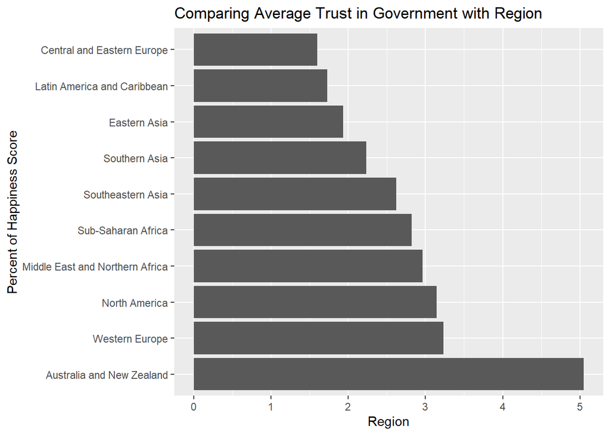

The plot shows that the regions of the world where trust in government contributes a greater percentage to the overall happiness score can be seen in more typically western areas, most notably Australia and New Zealand. I think this analysis can be beneficial to governments of different countries by giving them a standard of comparison as to where they stand, and a direction to start looking as to how they can improve. Some of the happiness factors (like generosity, for instance) are somewhat vague and unlikely to be impacted by a change in government policy, but the trust in government is something that could conceivably be adjusted.

### Jingzhi Zhang

How does the extent to which generosity contributed to the calculation of the happiness score vary by the region of the world in year 2017?

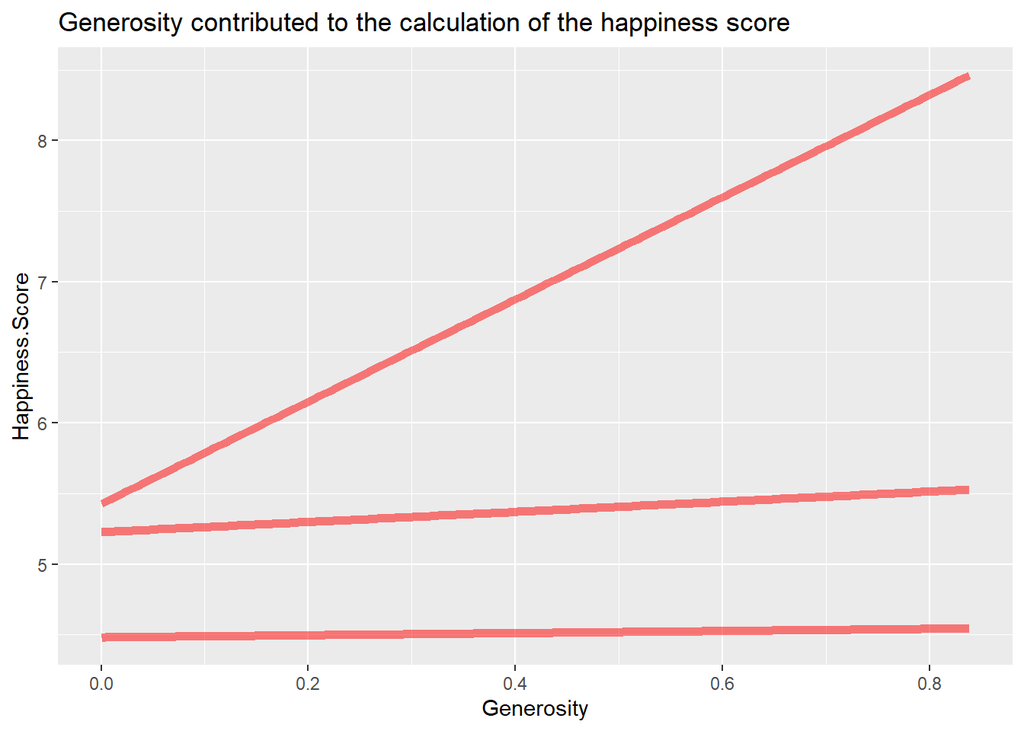

Findings: The pot shows that as the extent to which Generosity contributed to the calculation of the Happiness Score going up, the happiness score is going up. Therefore, there was a positive correlation between generosity and happiness score.

## Kaiyuan Fan

How does the extent to which contribution of dystopia residual to happiness score in each year?

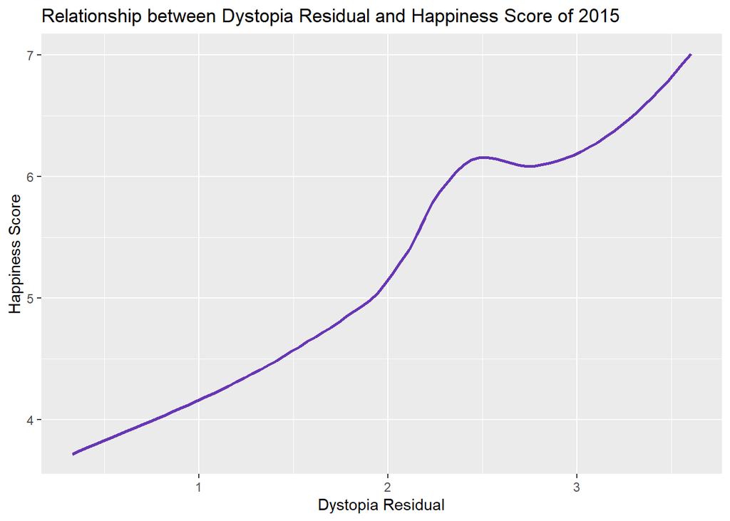

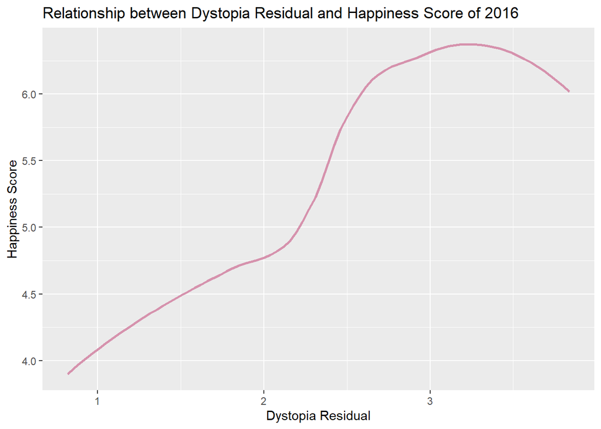

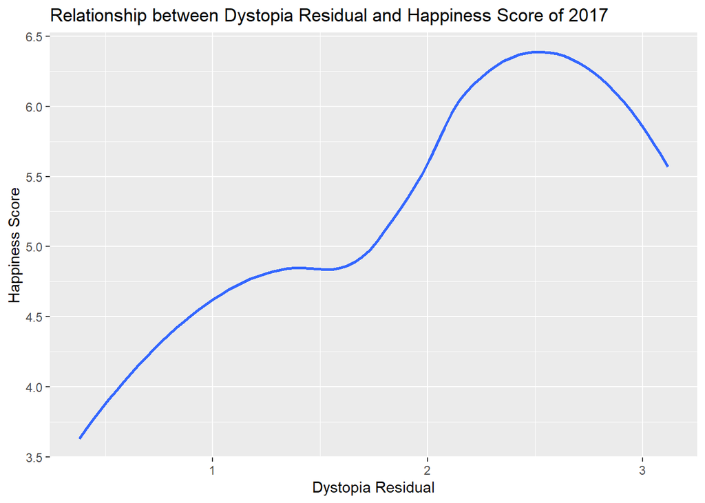

## Johnny Tamanaha

How does freedom affect the happiness score of a country?

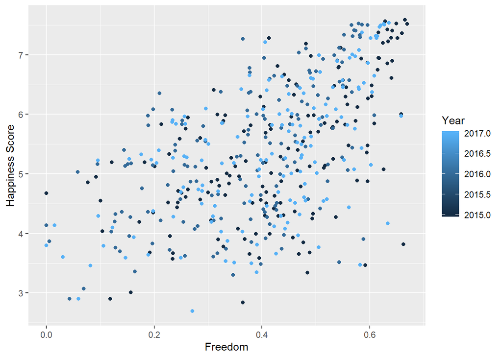

The scatterplot of freedom vs happiness score shows a general positive trend between the two variables, which makes logical sense because more freedom should lead to happier citizens.

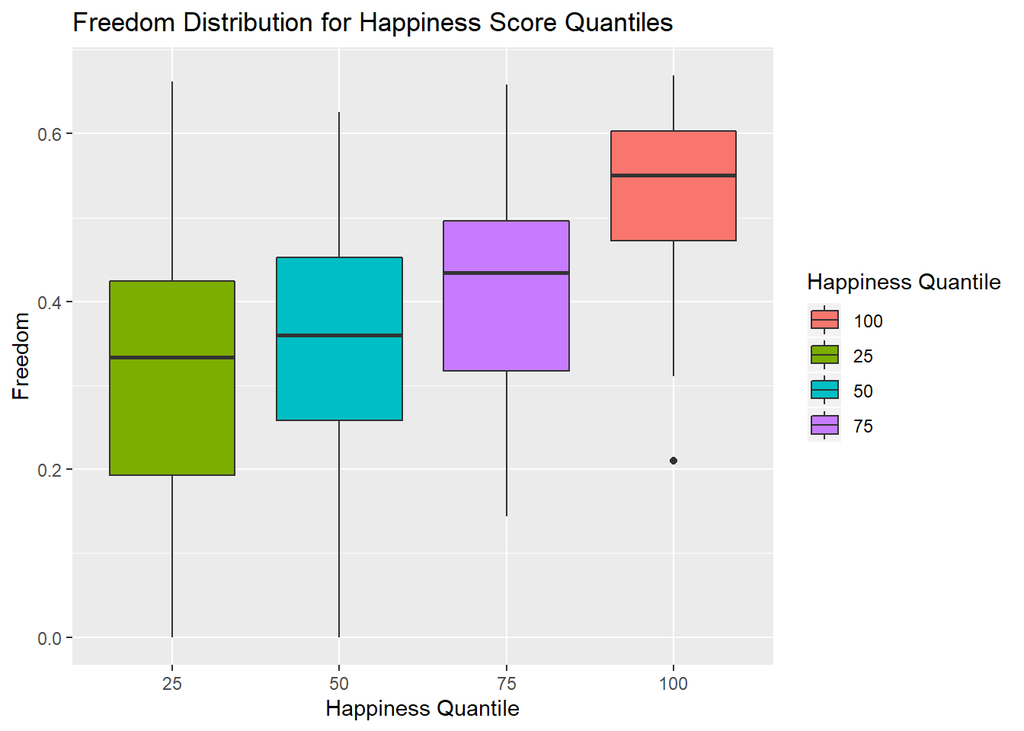

The boxplots show a trend of higher freedom for higher happiness quantiles, but more spread out freedom for lower happiness quantiles. This implies that freedom is a building block, but not necessarity sufficient for making happy citizens.

## Ethics:

This analysis seems to be contributing to the greater good, evaluating via proxy what makes people happy and what factors countries need to improve in order to improve the happiness of their population. However it does not evaluate why those factors are the state they are in, or how to remedy factors with low scores.

## Summary & Individual Contributions:

Eugene Miller: I created an individual plot and answered two individual questions, and contributed to the overall team question and plot. I used geom_col, geom_text, theme, guides, ggtitle, and labs to create my plot.

Emily Archambault: I created an individual plot examining the relationship between the trust in government happiness factor and the region of the world. I used geom_col, labs, and coord_flip to make the plot. In addition, I made one of the team plots and wrote the overall question importance.

Johnny Tamanaha: I created the individual plots for finding the relationship between freedom and happiness score. I used geom_point and geom_boxplot for plotting. I used both the color and fill aesthetics. I used labs, xlab, ylab, and scale_fill_discrete to label my graphs.

Jingzhi Zhang: I created an individual plot that show the relationship between generosity and happiness score. And there is a positive correlation between these two variables.